# Kashyap_HW3

Madhuri

2022-11-06

## Homework 3

### Question 1

```r
set.seed(1104)
#splitting data
df_split <- initial_split(df, prop = 0.7, strata = Survived)
df_train <- training(df_split)
df_test <- testing(df_split)
```

The training dataset has 623 observations (70% of 891 is 623), and the test dataset has 268 observations (the remaining 30%). So, the two datasets have the appropriate number of observations.

There are missing data in the training dataset, especially for the age variable.

It is a good idea to use stratified sampling for this data because stratified sampling makes it so that each group is accurately represented in the data. Also, stratified sampling on the outcome allows for the outcome to be distributed the same in both the training and testing datasets. That is, the proportions for survived and not survived will be the same in both datasets.

### Question 2

```r
# check frequency in training set
table(df_train$Survived)
```

```
##
##   0   1
## 384 239
```

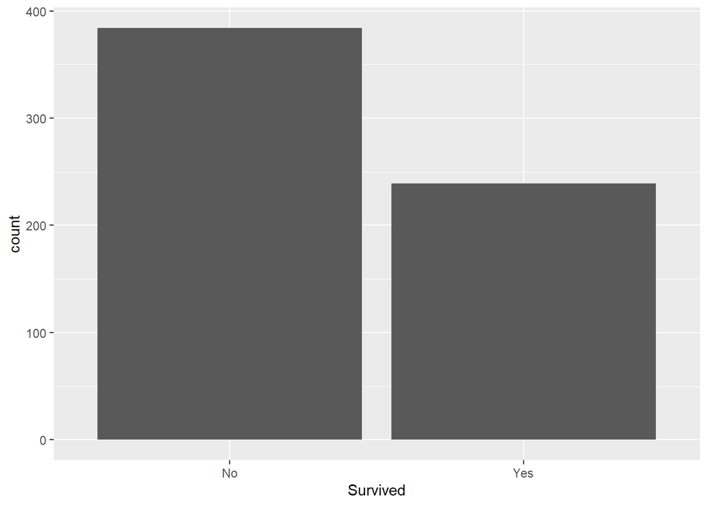

```r
##
## Yes No
## 239 384
# make a bar plot
df_train %>%
  ggplot(aes(x = Survived)) +
  geom_bar() +
  scale_x_discrete(labels = c("No","Yes"))
```

In the training set, 239 people survived and 384 people did not survive.